# **Classificazione della salute del feto**

Bonanomi Gervasoni Mahhadi

16 Gennaio 2024

#### *Abstract*

La lettura delle cardiotografie CTGs, che sono registrazioni grafiche (tracciati) della frequenza cardiaca fetale durante la gravidanza, è soggetta a interpretazioni differenti quando viene eseguita da diversi operatori sanitari. Si tratta di una fase essenziale per valutare la salute del feto durante la gravidanza e il travaglio. Essa infatti influenza le decisioni sull’intervento del medico che, a seconda di come viene valutato il feto, opterà ad esempio per la somministrazione di ossigeno alla madre, o in casi più gravi, procederà con un taglio cesareo d’emergenza.

Ulteriori dettagli sul dataset sono presenti al seguente link: [Fetal Health Classification-Kaggle](https://www.kaggle.com/datasets/andrewmvd/fetal-health-classification/data%3E)

### 1) Introduzione

La riduzione della mortalità neonatale fa parte dei principi cardine dell’Agenda 2030 per lo sviluppo sostenibile. Sottoscritta nel 2015 dai governi dei 193 membri delle Nazioni Unite, fra gli obiettivi che si prefigge vi è quello di porre fine alle morti prevenibili di neonati e bambini sotto i 5 anni di età. In particolare viene richiesto che tutti i paesi dovranno cercare di ridurre la mortalità neonatale ad almeno 12 per ogni 1000 abitanti nati vivi. Ad oggi però sono più di 60 gli stati lontani da questo traguardo e 2.3 milioni di neonati muoiono ogni anno. Di questi 904 400 neonati sopravvivono solo pochi giorni a causa di complicanze alla nascita, e oltre un milione sono quelli che muoiono durante il parto. La maggior parte di questi decessi sono causati dalla scarsa qualità dell’assistenza prima e durante il parto. Il miglioramento dei servizi sanitari e il potenziamento dei supporti informatici a costi accessibili,quindi, sono punti chiave per arginare queste tragedie.  
Fatte queste premesse, non si può non considerare la cardiotografia computerizzata CTGc vista la posizione di primaria importanza che occupa nel fornire l’ausilio al monitoraggio della salute del feto. Essa infatti è stata introdotta con l’obiettivo di ridurre i falsi positivi e la soggettività dell’interpretazione poichè fornisce un’interpretazione oggettiva della CTG consentendo la comunicazione di numeri piuttosto che di opinioni. Negli anni infatti ci si è resi conto che i risultati pratici conseguiti dall’uso «di massa» della cardiotocografia sono stati di gran lunga inferiori alle aspettative a causa della carenza di criteri univoci di interpretazione e a scarsa preparazione degli operatori sanitari.

### 2) Materiali

I dati di interesse sono stati estratti dal dataset **fetal_health**,esportabile gratuitamente dal link sopracitato. Si tratta di un dataset con 2126 osservazioni di cardiotografie fetali suddivise per 21 variabili a cui si somma l’etichetta di classe *fetal_health* rappresentata dalle seguenti modalità: 1,2,3 che indicano rispettivamente uno stato di salute del feto Normale, Sospetto, Patologico. Per completezza di informazione segue una tabella che riporta sinteticamente la descrizione e le modalità dell variabili:

| VARIABILE | DESCRIZIONE | MODALITÀ |
| --- | --- | --- |
| baseline_value | Valore di base della frequenza cardiaca fetale (FHR) | Bpm |
| accelerations | Conteggio delle accelerazioni medie dalla FHR | Hz |
| fetal_movement | Presenza media di movimenti fetali | Hz |
| uterine_contractions | Numero di contrazioni uterine | Hz |
| light_decelerations | Numero di decelerazioni leggere della FHR | Hz |
| severe_decelerations | Numero di decelerazioni gravi della FHR | Hz |
| prolongued_decelerations | Numero di decelerazioni prolungate della FHR | Hz |
| abnormal_short_term_variability | Presenza di variabilità a breve termine anormale | Binario (0 o 1) |
| mean_value_of_short_term_variability | Valore medio della variabilità a breve termine | Numerico |
| percentage_of_time_with_abnormal_long_term… | Percentuale di tempo con variabilità a lungo termine anormale | Percentuale |
| mean_value_of_long_term_variability | Valore medio della variabilità a lungo termine | Numerico |
| histogram_width | Larghezza dell’istogramma della FHR | Numerico |
| histogram_min | Valore minimo dell’istogramma della FHR | Numerico |
| histogram_max | Valore massimo dell’istogramma della FHR | Numerico |
| histogram_number_of_peaks | Numero di picchi nell’istogramma della FHR | Numerico (conteggio) |
| histogram_number_of_zeroes | Numero di zeri nell’istogramma della FHR | Numerico (conteggio) |
| histogram_mode | Modalità dell’istogramma della FHR | Numerico |
| histogram_mean | Valore medio dell’istogramma della FHR | Numerico |
| histogram_median | Mediana dell’istogramma della FHR | Numerico |
| histogram_variance | Varianza dell’istogramma della FHR | Numerico |
| histogram_tendency | Asimmetria dell’istogramma della FHR | **-1**: sinistra **0**:simmetrica **1**:destra |
| fetal_health | Salute fetale (etichetta di classe) | **1**: Sano **2**:Sospetto **3**:Patologico |

Il dataset non presenta valori mancanti. Valutando la distribuzione delle variabili abbiamo visto come quelle di conteggio naturalmente seguono una distribuzione assimilabile a quella di Poisson di conseguenza si è optato ad escluderle dalle successive analisi assieme alle variabili che dimostravano una pronunciata asimmetria. È stata esclusa anche la variabile histogram_tendency poichè fattoriale. Da un’analisi preliminare dell’istogramma delle frequenze relative condizionato per classi si evince come la classe dei sani è predominante:

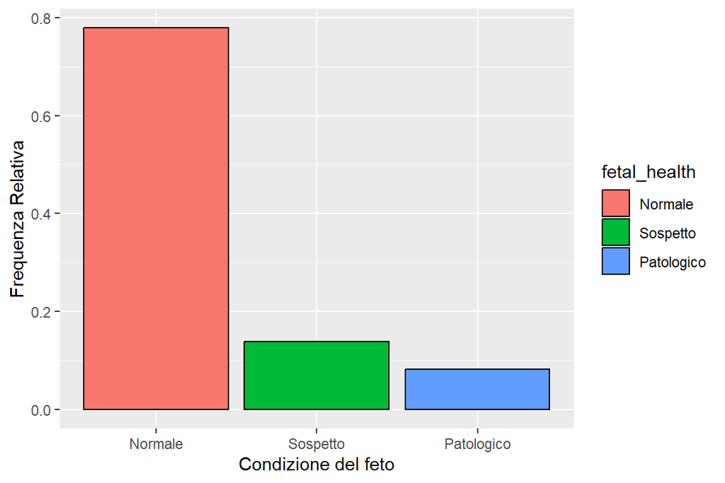

### 3) Analisi esplorativa

```
## [1] "histogram_mean"                      "histogram_max"
## [3] "mean_value_of_long_term_variability" "uterine_contractions"
```

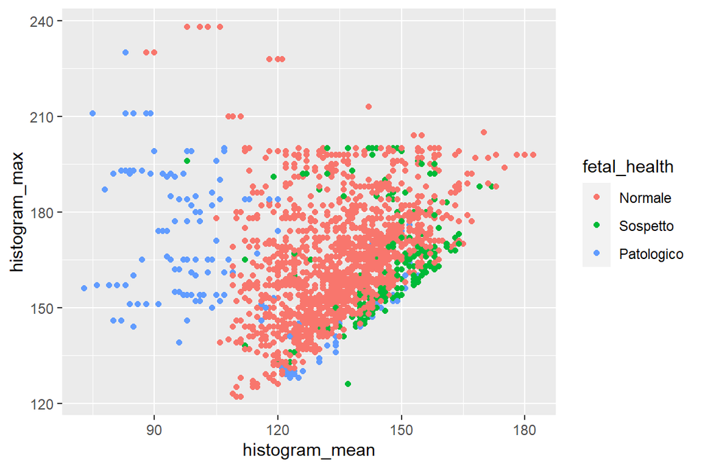

è evidente come i sospetti sul grafico si collocano a destra dei sani e non tra sani e malati, difatti i cardiotogrammi dei feti sospetti sono quelli cui parametri si discostano dalla normalità e che necessitano di ulteriori approfondimenti.

### 4.1) Model Based Clustering

Fatte le dovute analisi, per il clustering abbiamo optato per il dataset con le sole variabili selezionate tramite pca (non servono le etichette per il clustering).

```r
#dataset per model-based clustering:
(fetal_Health_EM<-fetal_Health%>%
  select(all_of(load_vars))) #dataset solo con le variabili selezionate tramite pca (non servono le etichette per il clustering)
```

```
## # A tibble: 2,126 × 4
##    histogram_mean histogram_max mean_value_of_long_term_v…¹ uterine_contractions
##             <dbl>         <dbl>                       <dbl>                <dbl>
##  1            137           126                         2.4                0
##  2            136           198                        10.4                0.006
##  3            135           198                        13.4                0.008
##  4            134           170                        23                  0.008
##  5            136           170                        19.9                0.008
##  6            107           200                         0                  0.01
##  7            107           200                         0                  0.013
##  8            122           130                        15.6                0
##  9            122           130                        13.6                0.002
## 10            122           130                        10.6                0.003
## # ℹ 2,116 more rows
## # ℹ abbreviated name: ¹mean_value_of_long_term_variability
```

```r
#dataset per model-based classification
(fetal_Health_classification <-fetal_Health%>%
  select(all_of(load_vars),fetal_health))
```

```
## # A tibble: 2,126 × 5
##    histogram_mean histogram_max mean_value_of_long_term_v…¹ uterine_contractions
##             <dbl>         <dbl>                       <dbl>                <dbl>
##  1            137           126                         2.4                0
##  2            136           198                        10.4                0.006
##  3            135           198                        13.4                0.008
##  4            134           170                        23                  0.008
##  5            136           170                        19.9                0.008
##  6            107           200                         0                  0.01
##  7            107           200                         0                  0.013
##  8            122           130                        15.6                0
##  9            122           130                        13.6                0.002
## 10            122           130                        10.6                0.003
## # ℹ 2,116 more rows
## # ℹ abbreviated name: ¹mean_value_of_long_term_variability
## # ℹ 1 more variable: fetal_health <fct>
```

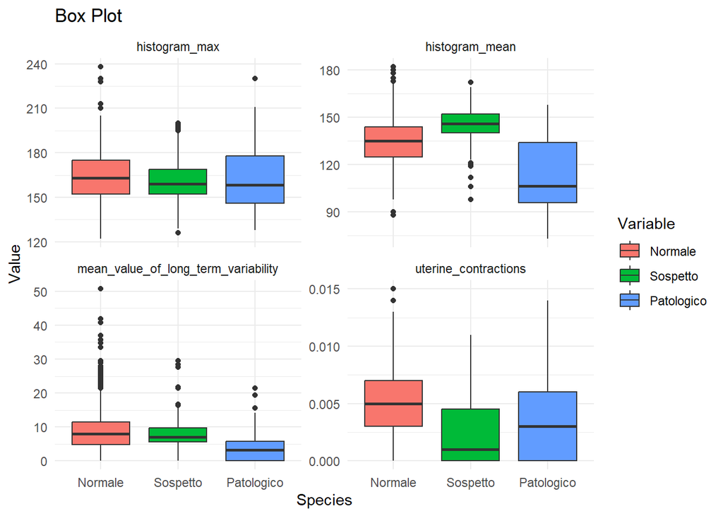

```r
fetal_Health_viz <- fetal_Health_classification %>%
  gather(key = "Variable", value = "Value", -fetal_health)

# Create a facetted box plot using ggplot2
ggplot(fetal_Health_viz, aes(x = fetal_health, y = Value, fill =fetal_health )) +
  geom_boxplot() +
  facet_wrap(~Variable, scales = "free_y", ncol = 2) +
  labs(title = "Box Plot",
       x = "Species",
       y = "Value",
       fill = "Variable") +
  theme_minimal()
```

a livello univariato non si evince particolare differenza tra i vari gruppi ad eccezione della variabile “histogram_mean”. Non si esclude che non vi sia corrispondenza a livello bivariato (scatterplot precedenti) o multivariato che non è verificabile con strumenti grafici.  
Si nota nuovamente, a sostegno delle osservazioni precedenti, che il gruppo dei sospetti risulta generalmente più simile al gruppo dei sani. Questo vale per 3 delle 4 variabili.  
Arrivati a questo punto, implementiamo un EM di normali senza specificare il numero dei gruppi:

```r
#install.packages("mclust")
set.seed(123)
health_mclust_ICL<-mclustICL(fetal_Health_EM, G=2:10) #l'algoritmo EM non riesce a stimare modelli complessi come VVV a causa della
#bassa disponibilità di u.s. (nemmeno VVV con k=3)
summary(health_mclust_ICL)
```

```
## Best ICL values:
##              VEV,7         EVV,3       VEV,10
## ICL      -29456.72 -29463.178690 -29534.63925
## ICL diff      0.00     -6.460372    -77.92093
```

Essendo un dataset con un numero relativamente limitato di osservazioni l’algoritmo EM non riesce a stimare dei modelli complessi come il VVV(nemmeno VVV con k=3),mentre osserviamo che VEV,7 e EVV,3 sono molto vicini tra loro. Notiamo inoltre dal grafico ottenuto come gran parte dei modelli in base all’ICL risultano della stessa precisione qualunque sia il numero di gruppi. Ipotizziamo che ciò può essere dato dal fatto che essendo dati reali è verosimile che ciascun gruppo abbia diversi sotto gruppi. Alla luce di ciò riteniamo oppurtono eseguire un MDA in fase di model-based classification.

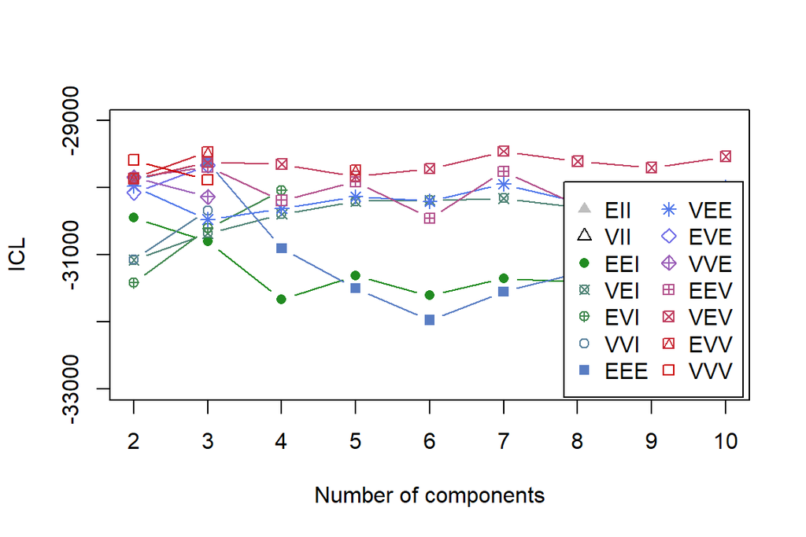

Provando a valutare il BIC (non accurato come ICL, in quanto non tiene conto dell’entropia) viene restituito un modello VEV k=8

```r
set.seed(123)
health_mclust_BIC<-Mclust(fetal_Health_EM,G=2:10)
summary(health_mclust_BIC)
```

```
## ----------------------------------------------------
## Gaussian finite mixture model fitted by EM algorithm
## ----------------------------------------------------
##
## Mclust VEV (ellipsoidal, equal shape) model with 8 components:
##
##  log-likelihood    n df      BIC       ICL
##       -13920.96 2126 98 -28592.8 -29604.72
##
## Clustering table:
##   1   2   3   4   5   6   7   8
## 107 352 578 363 125 309 162 130
```

SIA TRAMITE ICL SIA TRAMITE BIC IL MODEL BASED CLUSTERING FORNISCE UN NUMERO DI GRUPPI DIFFERENTE….PROVIAMO A SPECIFICARE IL NUMERO DI GRUPPI:

```r
set.seed(123)
health_mclust_ICL_k3<-mclustICL(fetal_Health_EM,G=3)
summary(health_mclust_ICL_k3) #EVV
```

```
## Best ICL values:
##              EVV,3       EEE,3       VEV,3
## ICL      -29463.18 -29613.7625 -29619.8340
## ICL diff      0.00   -150.5838   -156.6553
```

```r
str(health_mclust_ICL_k3)
```

```
##  'mclustICL' num [1, 1:14] -63900 -62973 -30800 -30677 -30605 ...
##  - attr(*, "G")= num 3
##  - attr(*, "modelNames")= chr [1:14] "EII" "VII" "EEI" "VEI" ...
##  - attr(*, "control")=List of 4
##   ..$ eps     : num 2.22e-16
##   ..$ tol     : num [1:2] 1.00e-05 1.49e-08
##   ..$ itmax   : int [1:2] 2147483647 2147483647
##   ..$ equalPro: logi FALSE
##  - attr(*, "initialization")=List of 3
##   ..$ hcPairs: 'hc' num [1:2, 1:1999] 1088 1985 224 1088 224 ...
##   .. ..- attr(*, "initialPartition")= num [1:2000] 1 2 3 4 5 6 7 8 9 10 ...
##   .. .. ..- attr(*, "unique")= int 2000
##   .. ..- attr(*, "dimensions")= int [1:2] 2000 4
##   .. ..- attr(*, "modelName")= chr "VVV"
##   .. ..- attr(*, "call")= language hc(data = data[subset, ], modelName = mclust.options("hcModelName"), use = mclust.options("hcUse"))
##   .. ..- attr(*, "use")= chr "SVD"
##   .. ..- attr(*, "data")= num [1:2000, 1:4] 0.361 0.112 -0.129 -0.17 -0.123 ...
##   ..$ subset : int [1:2000] 526 195 1842 1142 1253 1268 1038 665 1627 1011 ...
##   ..$ noise  : NULL
##  - attr(*, "warn")= logi FALSE
##  - attr(*, "n")= int 2126
##  - attr(*, "d")= int 4
##  - attr(*, "oneD")= logi FALSE
##  - attr(*, "criterion")= chr "ICL"
##  - attr(*, "returnCodes")= num [1, 1:14] 0 0 0 0 0 0 0 0 0 0 ...
##   ..- attr(*, "dimnames")=List of 2
##   .. ..$ : chr "3"
##   .. ..$ : chr [1:14] "EII" "VII" "EEI" "VEI" ...
##  - attr(*, "dimnames")=List of 2
##   ..$ : chr "3"
##   ..$ : chr [1:14] "EII" "VII" "EEI" "VEI" ...
```

```r
set.seed(123)
health_mclust_BIC_k3<-Mclust(fetal_Health_EM,G=3)
summary(health_mclust_BIC_k3) #EVV
```

```
## ----------------------------------------------------
## Gaussian finite mixture model fitted by EM algorithm
## ----------------------------------------------------
##
## Mclust EVV (ellipsoidal, equal volume) model with 3 components:
##
##  log-likelihood    n df       BIC       ICL
##       -14407.42 2126 42 -29136.65 -29463.18
##
## Clustering table:
##    1    2    3
##  161 1620  345
```

in questo caso ICL e BIC restituiscono lo stesso modello (se fossero diversi sarebbe opportuno dare piorità al modello fornito tramite ICL)

```r
etichette_stimate<-health_mclust_BIC_k3$classification
precisione_EM<-classError(etichette_stimate, class=etichette)
accuracy<-1-length(precisione_EM$misclassified)/n
```

```r
(etichette_stimate<-as.factor(etichette_stimate))
```

[output not shown]

[output cut: 44 more lines]

```r
levels(etichette_stimate)<-c("Patologico","Normale","Sospetto")
confusionMatrix(etichette_stimate,etichette)
```

```
## Confusion Matrix and Statistics
##
##             Reference
## Prediction   Normale Sospetto Patologico
##   Normale       1291      253         76
##   Sospetto       284       39         22
##   Patologico      80        3         78
##
## Overall Statistics
##
##                Accuracy : 0.6623
##                  95% CI : (0.6417, 0.6824)
##     No Information Rate : 0.7785
##     P-Value [Acc > NIR] : 1.0000000
##
##                   Kappa : 0.1066
##
##  Mcnemar's Test P-Value : 0.0009693
##
## Statistics by Class:
##
##                      Class: Normale Class: Sospetto Class: Patologico
## Sensitivity                  0.7801         0.13220           0.44318
## Specificity                  0.3015         0.83288           0.95744
## Pos Pred Value               0.7969         0.11304           0.48447
## Neg Pred Value               0.2806         0.85626           0.95013
## Prevalence                   0.7785         0.13876           0.08278
## Detection Rate               0.6072         0.01834           0.03669
## Detection Prevalence         0.7620         0.16228           0.07573
## Balanced Accuracy            0.5408         0.48254           0.70031
```

la sensitivity è molto alta solo nella classe “Normale” al contrario la specificity è molto bassa (significa che tra patologico e normale non riesce ad ottenere una buonma divisione) in generale si può dire che i gruppi “Sospetto” e “Patologico” non sono rilevati correttamente dall’EM ES: 253 casi sospetti che vengono classificati come “Normali”

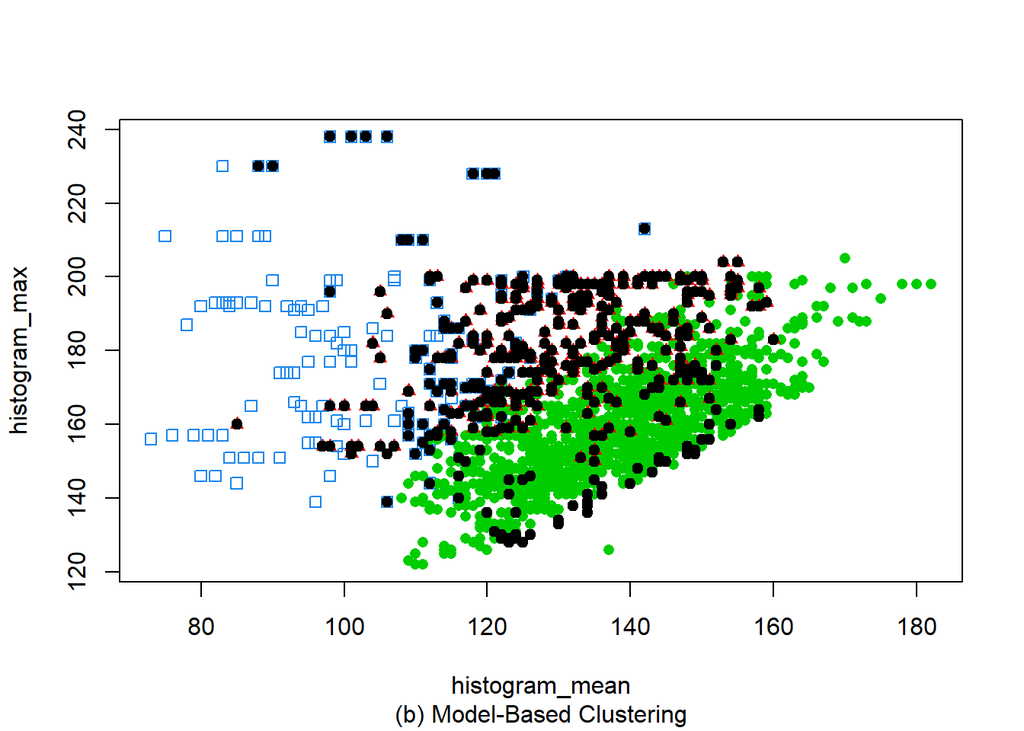

```r
coordProj (as.data.frame(fetal_Health_EM), dimens=c(1,2), what="classification",
           classification=health_mclust_BIC_k3$classification,
           col=c("dodgerblue2","green3","red2"), symbols=c(0 ,16 ,17),
           sub="(b) Model-Based Clustering")
points(fetal_Health_EM[precisione_EM$misclassified,c(1,2)],pch=19)
```

rappresentazione in nero delle u.s. missclassified si osserva che quanto meno le u.s. facenti parte del gruppo dei malati vengono allocate correttamente

questo grafico rappresenta l’incertezza delle u.s.:

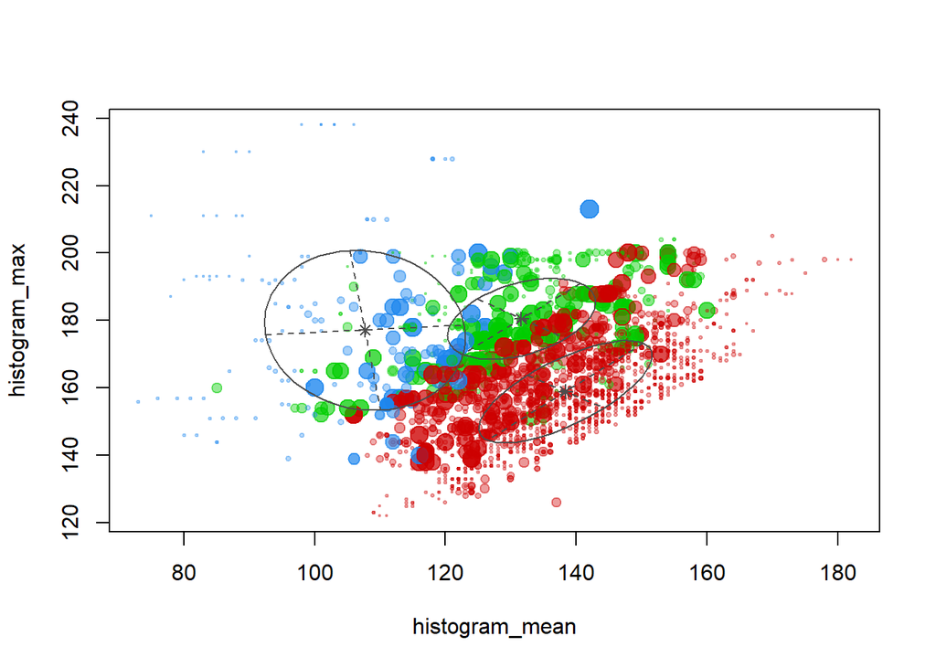

```r
coordProj (data=as.data.frame(fetal_Health_EM), dimens=c(1,2), what="uncertainty",
           parameters=health_mclust_BIC_k3$parameters , z=health_mclust_BIC_k3$z)
```

### Classification

funzione per eseguire una suddivisione in train set e test set:

```r
train_test<-function(data,perc=0.7){
  set.seed(123)
  index<-sample(c("train","test"),size=nrow(data),replace=T,prob=c(perc,1-perc))
  train<-data[index=="train",]
  test<-data[index=="test",]
  lis<-list(data_train=train,
            data_test=test)
  return(lis)
}
#costruzione train e test set per classification:
out<-train_test(fetal_Health_classification,0.7)
data_train<-out$data_train
data_test<-out$data_test
```

```r
set.seed(123)
(pr<-mixmodLearn(data_train[,1:4], c(data_train$fetal_health),
                 models=mixmodGaussianModel(family='all'),
                 criterion=c('CV','BIC')))
```

```
## *** INPUT:
## * nbCluster =  3
## * criterion =  CV BIC
## *** MIXMOD Models:
## * list =  Gaussian_pk_L_I Gaussian_pk_Lk_I Gaussian_pk_L_B Gaussian_pk_Lk_B Gaussian_pk_L_Bk Gaussian_pk_Lk_Bk Gaussian_pk_L_C Gaussian_pk_Lk_C Gaussian_pk_L_D_Ak_D Gaussian_pk_Lk_D_Ak_D Gaussian_pk_L_Dk_A_Dk Gaussian_pk_Lk_Dk_A_Dk Gaussian_pk_L_Ck Gaussian_pk_Lk_Ck Gaussian_p_L_I Gaussian_p_Lk_I…
## * This list includes models with free and equal proportions.
## * data (limited to a 10x10 matrix) =
##       histogram_mean histogram_max mean_value_of_long_term_variability
##  [1,] 137            126           2.4
##  [2,] 135            198           13.4
##  [3,] 107            200           0
##  [4,] 107            200           0
##  [5,] 122            130           13.6
##  [6,] 122            130           10.6
##  [7,] 148            186           29.5
##  [8,] 134            154           12.9
##  [9,] 137            158           5.4
## [10,] 125            174           7.9
##       uterine_contractions
##  [1,] 0
##  [2,] 0.008
##  [3,] 0.01
##  [4,] 0.013
##  [5,] 0.002
##  [6,] 0.003
##  [7,] 0.001
##  [8,] 0.008
##  [9,] 0.006
## [10,] 0.004
## * ... ...
## * knownLabels =  2 1 3 3 3 3 2 1 1 1  ...
##
##
## *** BEST MODEL OUTPUT:
## *** According to the CV criterion
## * nbCluster   =  3
## * model name  =  Gaussian_pk_Lk_Ck
## * criterion   =  CV(0.1639) BIC(22670.0074)
## * likelihood  =  -11174.1863
## *** Cluster 1
```

[output cut: 13 more lines]

```
## *** Cluster 3
## * proportion =  0.0816
## * means      =  111.9590 161.6721 3.4779 0.0039
## * variances  = |   531.1541  -209.3577    39.0975    -0.0512 |
##                |  -209.3577   434.5810   -10.4712     0.0325 |
##                |    39.0975   -10.4712    16.3548    -0.0045 |
##                |    -0.0512     0.0325    -0.0045     0.0000 |
## * Classification with MAP:
##            | Cluster 1 | Cluster 2 | Cluster 3 |
## ----------- ----------- ----------- -----------
##  Cluster 1 |      1160 |         0 |         0 |
##  Cluster 2 |         0 |       213 |         0 |
##  Cluster 3 |         0 |         0 |       122 |
## ----------- ----------- ----------- -----------
## * Error rate with MAP =  0.00 %
```

```r
summary(pr) #la parte di evaluation deve essere svolta sul test set
```

```
## * Number of samples    =  1495
## * Problem dimension    =  4
## *       Number of cluster =  3
## *              Model Type =  Gaussian_pk_Lk_Ck
## *               Criterion =  CV(0.1639) BIC(22670.0074)
## *              Parameters =  list by cluster
## *                  Cluster  1 :
##                          Proportion =  0.7759
##                               Means =  134.6560 164.2784 8.6845 0.0047
##                           Variances = |   170.4757    77.5863     2.0709    -0.0042 |
##                                       |    77.5863   329.6492    -2.1734     0.0021 |
##                                       |     2.0709    -2.1734    32.7168    -0.0013 |
##                                       |    -0.0042     0.0021    -0.0013     0.0000 |
## *                  Cluster  2 :
##                          Proportion =  0.1425
##                               Means =  144.4178 162.1549 8.0122 0.0024
##                           Variances = |   108.5813    59.5691     3.6315     0.0056 |
##                                       |    59.5691   282.9103    25.5422     0.0122 |
##                                       |     3.6315    25.5422    13.4344     0.0009 |
##                                       |     0.0056     0.0122     0.0009     0.0000 |
## *                  Cluster  3 :
##                          Proportion =  0.0816
##                               Means =  111.9590 161.6721 3.4779 0.0039
##                           Variances = |   531.1541  -209.3577    39.0975    -0.0512 |
##                                       |  -209.3577   434.5810   -10.4712     0.0325 |
##                                       |    39.0975   -10.4712    16.3548    -0.0045 |
##                                       |    -0.0512     0.0325    -0.0045     0.0000 |
## *          Log-likelihood =  -11174.1863
```

```r
PREDICTION<- mixmodPredict(data = select(data_test,-fetal_health), classificationRule=pr["bestResult"])
etichette_prediction_EDDA <- as.factor(PREDICTION@partition)
levels(etichette_prediction_EDDA) <- c("Normale","Sospetto", "Patologico")
(confmatrix <-confusionMatrix(etichette_prediction_EDDA,  data_test$fetal_health))
```

```
## Confusion Matrix and Statistics
##
##             Reference
## Prediction   Normale Sospetto Patologico
##   Normale        476       44         14
##   Sospetto        17       37         18
##   Patologico       2        1         22
##
## Overall Statistics
##
##                Accuracy : 0.8479
##                  95% CI : (0.8174, 0.875)
##     No Information Rate : 0.7845
##     P-Value [Acc > NIR] : 3.576e-05
##
##                   Kappa : 0.5214
##
##  Mcnemar's Test P-Value : 6.923e-08
##
## Statistics by Class:
##
##                      Class: Normale Class: Sospetto Class: Patologico
## Sensitivity                  0.9616         0.45122           0.40741
## Specificity                  0.5735         0.93625           0.99480
## Pos Pred Value               0.8914         0.51389           0.88000
## Neg Pred Value               0.8041         0.91950           0.94719
## Prevalence                   0.7845         0.12995           0.08558
## Detection Rate               0.7544         0.05864           0.03487
## Detection Prevalence         0.8463         0.11410           0.03962
## Balanced Accuracy            0.7676         0.69373           0.70110
```

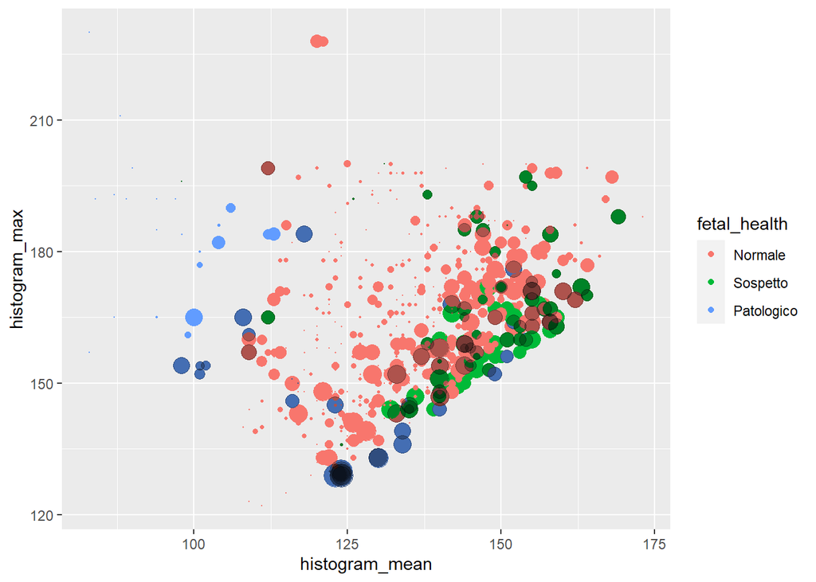

```r
prob.post_incertezza<- tibble(PREDICTION@proba) %>%
  rowwise() %>% # operiamo riga per riga
  mutate(incertezza = 1 - max(c_across(everything())))
data_test %>%
  ggplot(mapping = aes(x=histogram_mean , y = histogram_max, color = fetal_health)) +
  geom_point(size=prob.post_incertezza$incertezza*10)+
  geom_point(data = filter(data_test,etichette_prediction_EDDA != data_test$fetal_health ),
             color = "black", alpha = 0.3,size=prob.post_incertezza$incertezza[etichette_prediction_EDDA != data_test$fetal_health]*10)
```

maggior incertezza nella sezione del grafico in cui sono presenti gli individui sospetti

### MDA

```r
set.seed(123)
mod2 <- MclustDA(data_train[,1:4], data_train$fetal_health)
summary(mod2)
```

```
## ------------------------------------------------
## Gaussian finite mixture model for classification
## ------------------------------------------------
##
## MclustDA model summary:
##
##  log-likelihood    n  df      BIC
##       -9594.335 1495 135 -20175.5
##
## Classes         n     % Model G
##   Normale    1160 77.59   VVE 4
##   Sospetto    213 14.25   VEE 5
##   Patologico  122  8.16   EVV 4
##
## Training confusion matrix:
##             Predicted
## Class        Normale Sospetto Patologico
##   Normale       1088       44         28
##   Sospetto       104      102          7
##   Patologico      27       14         81
## Classification error = 0.1498
## Brier score          = 0.1091
```

```r
etichette_prediction_MDA<-predict(mod2, select(data_test,-fetal_health))$class
confusionMatrix(etichette_prediction_MDA, data_test$fetal_health)
```

```
## Confusion Matrix and Statistics
##
##             Reference
## Prediction   Normale Sospetto Patologico
##   Normale        462       40          8
##   Sospetto        28       37          8
##   Patologico       5        5         38
##
## Overall Statistics
##
##                Accuracy : 0.851
##                  95% CI : (0.8208, 0.8779)
##     No Information Rate : 0.7845
##     P-Value [Acc > NIR] : 1.441e-05
##
##                   Kappa : 0.5675
##
##  Mcnemar's Test P-Value : 0.3205
##
## Statistics by Class:
##
##                      Class: Normale Class: Sospetto Class: Patologico
## Sensitivity                  0.9333         0.45122           0.70370
## Specificity                  0.6471         0.93443           0.98267
## Pos Pred Value               0.9059         0.50685           0.79167
## Neg Pred Value               0.7273         0.91935           0.97256
## Prevalence                   0.7845         0.12995           0.08558
## Detection Rate               0.7322         0.05864           0.06022
## Detection Prevalence         0.8082         0.11569           0.07607
## Balanced Accuracy            0.7902         0.69282           0.84319
```

rimane la classe dei sospetti la più problematica stando ai valori di sensitivity (bassa in patologico) e specificity (alta in patologico) in ogni caso la classificazione tramite MDA risulta migliore di quella eseguita attraverso il modello EDDA

[figure not shown]

```r
prob.post_incertezza<- tibble(PREDICTION@proba) %>%
  rowwise() %>% # operiamo riga per riga
  mutate(incertezza = 1 - max(c_across(everything())))

data_test %>%
  ggplot(mapping = aes(x=histogram_mean , y = histogram_max, color = fetal_health)) +
  geom_point(size=prob.post_incertezza$incertezza*10)+
  geom_point(data = filter(data_test,etichette_prediction_EDDA != data_test$fetal_health ),
             color = "black", alpha = 0.3,size=prob.post_incertezza$incertezza[etichette_prediction_EDDA != data_test$fetal_health]*10) #
```

in nero la u.s. missclassified maggior incertezza nella sezione del grafico in cui sono presenti gli individui sospetti

riesce a predirre un 85 % la sensitivity del caso patologico è inferiore rispetto ad un valore soddisfacente, si può ipotizzare un oversampling

```r
accuracy<-function(g,mod,nCV=5,data,etichette){
  set.seed(123)
  mod_mda<-MclustDA(data,class=etichette,G=as.list(g),modelName=mod)
  return(1-cvMclustDA(mod_mda,nfold=nCV)$ce)
}

#funzione che valuta il miglior modello mda tramite cross validation con nfold=4 e restituisce il più accurato:
modello_MDA_k3<-function(data,etichette){
  g1<-g2<-g3<-c(1,2,3,4,5)
  g1<-as.data.frame(g1)
  g2<-as.data.frame(g2)
  g3<-as.data.frame(g3)
  join<-cross_join(cross_join(g1,g2),g3)
  join["mod"]<-"VII" #altrimenti con più modelli il codice impegherebbe troppo tempo
  #usiamo come alternativa il modello VII  che sono delle ipersfere del quale varia solo il volume
  out<-apply(join,MARGIN=1,function(pos) accuracy(g=pos[1:3],mod=pos[4],nCV=4,data=data,etichette=etichette))
  lis<-list(modello=join[which.max(out),],accuracy=out[which.max(out)]) #questa accuracy non è valida siccome è stimata sullo stesso dataset usato
  #per allenaere il modello (fuori dalla funzione viene valutato su un test set)
  return(lis)
}


(out<-modello_MDA_k3(data_train[,1:4],as.factor(data_train$fetal_health))) #G=(5,4,5)
```

```
## $modello
##     g1 g2 g3 mod
## 120  5  4  5 VII
##
## $accuracy
## [1] 0.8434783
```

```r
#stimiasmo il modello migliore e sul test set forniamo la precisione tramite accuracy e la confusion matrix

set.seed(123)
mod_mda_k3<-MclustDA(data_train[,1:4],data_train$fetal_health,G=c(5,4,5),modelNames="VII")
etichette_prediction_MDA_cv<-predict(mod_mda_k3, select(data_test,-fetal_health))$class
confusionMatrix(etichette_prediction_MDA_cv, data_test$fetal_health)
```

```
## Confusion Matrix and Statistics
##
##             Reference
## Prediction   Normale Sospetto Patologico
##   Normale        453       37         12
##   Sospetto        34       43          8
##   Patologico       8        2         34
##
## Overall Statistics
##
##                Accuracy : 0.8399
##                  95% CI : (0.809, 0.8677)
##     No Information Rate : 0.7845
##     P-Value [Acc > NIR] : 0.000283
##
##                   Kappa : 0.5458
##
##  Mcnemar's Test P-Value : 0.209916
##
## Statistics by Class:
##
##                      Class: Normale Class: Sospetto Class: Patologico
## Sensitivity                  0.9152         0.52439           0.62963
## Specificity                  0.6397         0.92350           0.98267
## Pos Pred Value               0.9024         0.50588           0.77273
## Neg Pred Value               0.6744         0.92857           0.96593
## Prevalence                   0.7845         0.12995           0.08558
## Detection Rate               0.7179         0.06815           0.05388
## Detection Prevalence         0.7956         0.13471           0.06973
## Balanced Accuracy            0.7774         0.72394           0.80615
```

fatica in “Sospetto” e “Patologico” abbiamo aumentato la sensitivity del caso “sospetto” ma peggiorato quello del caso “patologico”

implementare un MDA con lo scopo di classificare gli individui “sospetti” in una delle altre 2 classi funzione per un modello mda con soli 2 gruppi:

```r
modello_MDA_k2<-function(data,etichette){
  g1<-g2<-c(1,2,3,4,5)
  g1<-as.data.frame(g1)
  g2<-as.data.frame(g2)
  join<-cross_join(g1,g2)
  join["mod"]<-"VII" #altrimenti con più modelli il codice impegherebbe troppo tempo
  #usiamo come alternativa il modello VII  che sono delle ipersfere del quale varia solo il volume
  out<-apply(join,MARGIN=1,function(pos) accuracy(g=pos[1:2],mod=pos[3],nCV=4,data=data,etichette=etichette))
  lis<-list(modello=join[which.max(out),],accuracy=out[which.max(out)])
  return(lis)
}


(fetal_Health_no_sospetti<-fetal_Health_classification%>%
  filter(fetal_health!="Sospetto"))
```

```
## # A tibble: 1,831 × 5
##    histogram_mean histogram_max mean_value_of_long_term_v…¹ uterine_contractions
##             <dbl>         <dbl>                       <dbl>                <dbl>
##  1            136           198                        10.4                0.006
##  2            135           198                        13.4                0.008
##  3            134           170                        23                  0.008
##  4            136           170                        19.9                0.008
##  5            107           200                         0                  0.01
##  6            107           200                         0                  0.013
##  7            122           130                        15.6                0
##  8            122           130                        13.6                0.002
##  9            122           130                        10.6                0.003
## 10            134           154                        12.9                0.008
## # ℹ 1,821 more rows
## # ℹ abbreviated name: ¹mean_value_of_long_term_variability
## # ℹ 1 more variable: fetal_health <fct>
```

```r
(etichette_k2<-as.factor(fetal_Health_no_sospetti$fetal_health))
```

[output not shown]

[output cut: 292 more lines]

```r
levels(etichette_k2)<-c("Normale","Normale","Patologico")
modello_MDA_k2(fetal_Health_no_sospetti[,1:4],etichette_k2)
```

```
## $modello
##    g1 g2 mod
## 19  4  4 VII
##
## $accuracy
## [1] 0.9579465
```

```r
set.seed(123)
mod_mda_k2<-MclustDA(fetal_Health_no_sospetti[,1:4],etichette_k2,G=4,modelNames="VII") #G=(4,4)
summary(mod_mda_k2)
```

```
## ------------------------------------------------
## Gaussian finite mixture model for classification
## ------------------------------------------------
##
## MclustDA model summary:
##
##  log-likelihood    n df      BIC
##       -26181.66 1831 46 -52708.9
##
## Classes         n     % Model G
##   Normale    1655 90.39   VII 4
##   Patologico  176  9.61   VII 4
##
## Training confusion matrix:
##             Predicted
## Class        Normale Patologico
##   Normale       1630         25
##   Patologico      47        129
## Classification error = 0.0393
## Brier score          = 0.0346
```

```r
(fetal_Healt_sospetti<-fetal_Health_classification%>%
  filter(fetal_health=="Sospetto"))
```

```
## # A tibble: 295 × 5
##    histogram_mean histogram_max mean_value_of_long_term_v…¹ uterine_contractions
##             <dbl>         <dbl>                       <dbl>                <dbl>
##  1            137           126                         2.4                0
##  2            148           186                        27.6                0.001
##  3            148           186                        29.5                0.001
##  4            125           174                        13.9                0.003
##  5            119           191                        10.5                0.001
##  6            131           200                         3.3                0.011
##  7            152           161                         6.2                0
##  8            148           184                        12.8                0
##  9            148           184                        13.2                0
## 10            158           166                        13.4                0.004
## # ℹ 285 more rows
## # ℹ abbreviated name: ¹mean_value_of_long_term_variability
## # ℹ 1 more variable: fetal_health <fct>
```

```r
table(predict(mod_mda_k2,fetal_Healt_sospetti[,1:4])$class)/nrow(fetal_Healt_sospetti)
```

```
##
##    Normale Patologico
##  0.8677966  0.1322034
```

stando ai dati si evince che nella gran parte dei casi “sospetti” apparterrebbero alla classe normale

### MDA under/oversampling

idea del modello: basandosi sull’analisi precedente nel quale 7 individui su 8 della classe dei sospetti sono classificati nella normali, non avendo certezze scientifiche sul futuro del feto essendo dati anomali ma sul quale la ricerca in campo medico non è sufficientemente approfondita; vista la difficoltà dei modelli nel classificare la classe dei sospetti (sensitivity troppo bassa) costruiamo un modello solo con lo scopo di classificare un feto come patologico o no…senza suddividere i dati in normale e sospetto

```r
# install.packages("grid")
# install.packages( "https://cran.r-project.org/src/contrib/Archive/DMwR/DMwR_0.4.1.tar.gz", repos=NULL, type="source" )
# install.packages("DMwR")
# install.packages("ROCR")

library(lattice)
library(grid)
library(DMwR)
(train2<-data_train %>%
  as.data.frame())
```

[output not shown]

[output cut: 2977 more lines]

```r
table(train2$fetal_health)
```

```
##
##    Normale   Sospetto Patologico
##       1160        213        122
```

```r
levels(train2$fetal_health) <- c("Normale","Normale","Patologico") # i sospetti vengono considerati normali (vedi definizione patologici)
table(train2$fetal_health)
```

```
##
##    Normale Patologico
##       1373        122
```

```r
new_train <- SMOTE(fetal_health ~ ., train2, perc.over= 600, perc.under = 117)
table(new_train$fetal_health)
```

```
##
##    Normale Patologico
##        856        854
```

SMOTE è un algoritmo di bilanciamento dei dati utilizzato per affrontare il problema dei dataset sbilanciati. Genera sinteticamente nuovi esempi per la classe minoritaria, identificando vicini prossimi e creando combinazioni lineari tra le istanze esistenti. Questo processo migliora la rappresentazione della classe meno frequente nel dataset, aiutando i modelli di machine learning a generalizzare meglio durante l’addestramento. La corretta regolazione dei parametri, come il numero di vicini, è essenziale per evitare eccessiva generazione di dati sintetici. In generale, l’applicazione di SMOTE contribuisce a una classificazione più accurata delle classi minoritarie in un contesto di dataset sbilanciati.

if 200 new examples were generated for the minority class, a value of perc.under of 100 will randomly select exactly 200 cases belonging to the majority classes from the original data set to belong to the final data set. Values above 100 will select more examples from the majority classes. in questo caso prendiamo (+ perc.over/100 %) * ncasi * perc.under

```r
mm <-mixmodGaussianModel(family = "all",
                                        free.proportions = F) #modello in cui i pj non sono stimati siccome vengono imposti pari a circa 0.5 dall'azione
#di oversampling e undersampling
modsmote <- mixmodLearn(new_train[,-5], new_train$fetal_health ,models=mm,
                        criterion = "CV")
modsmote@bestResult
```

```
## * nbCluster   =  2
## * model name  =  Gaussian_p_Lk_D_Ak_D
## * criterion   =  CV(0.1421)
## * likelihood  =  -12978.8295
## *** Cluster 1
## * proportion =  0.5000
## * means      =  135.8411 163.4661 8.4157 0.0044
## * variances  = |   196.6030    96.7137     9.1000    -0.0122 |
##                |    96.7137   306.6847     3.0638     0.0034 |
##                |     9.1000     3.0638    28.4639    -0.0022 |
##                |    -0.0122     0.0034    -0.0022     0.0000 |
## *** Cluster 2
## * proportion =  0.5000
## * means      =  111.7817 161.2024 3.3816 0.0039
## * variances  = |   565.7903  -186.4403    34.7999    -0.0523 |
##                |  -186.4403   356.0390   -14.4205     0.0280 |
##                |    34.7999   -14.4205    13.2834    -0.0040 |
##                |    -0.0523     0.0280    -0.0040     0.0000 |
## * Classification with MAP:
##            | Cluster 1 | Cluster 2 |
## ----------- ----------- -----------
##  Cluster 1 |       856 |         0 |
##  Cluster 2 |         0 |       854 |
## ----------- ----------- -----------
## * Error rate with MAP =  0.00 %
```

```r
summary(modsmote)
```

```
## * Number of samples    =  1710
## * Problem dimension    =  4
## *       Number of cluster =  2
## *              Model Type =  Gaussian_p_Lk_D_Ak_D
## *               Criterion =  CV(0.1421)
## *              Parameters =  list by cluster
## *                  Cluster  1 :
##                          Proportion =  0.5000
##                               Means =  135.8411 163.4661 8.4157 0.0044
##                           Variances = |   196.6030    96.7137     9.1000    -0.0122 |
##                                       |    96.7137   306.6847     3.0638     0.0034 |
##                                       |     9.1000     3.0638    28.4639    -0.0022 |
##                                       |    -0.0122     0.0034    -0.0022     0.0000 |
## *                  Cluster  2 :
##                          Proportion =  0.5000
##                               Means =  111.7817 161.2024 3.3816 0.0039
##                           Variances = |   565.7903  -186.4403    34.7999    -0.0523 |
##                                       |  -186.4403   356.0390   -14.4205     0.0280 |
##                                       |    34.7999   -14.4205    13.2834    -0.0040 |
##                                       |    -0.0523     0.0280    -0.0040     0.0000 |
## *          Log-likelihood =  -12978.8295
```

```r
PREDICTION<- mixmodPredict(data = select(data_test,-fetal_health), classificationRule=modsmote["bestResult"])
PREDICTION@classificationRule
```

```
## * nbCluster   =  2
## * model name  =  Gaussian_p_Lk_D_Ak_D
## * criterion   =  CV(0.1421)
## * likelihood  =  -12978.8295
## *** Cluster 1
## * proportion =  0.5000
## * means      =  135.8411 163.4661 8.4157 0.0044
## * variances  = |   196.6030    96.7137     9.1000    -0.0122 |
##                |    96.7137   306.6847     3.0638     0.0034 |
##                |     9.1000     3.0638    28.4639    -0.0022 |
##                |    -0.0122     0.0034    -0.0022     0.0000 |
## *** Cluster 2
## * proportion =  0.5000
## * means      =  111.7817 161.2024 3.3816 0.0039
## * variances  = |   565.7903  -186.4403    34.7999    -0.0523 |
##                |  -186.4403   356.0390   -14.4205     0.0280 |
##                |    34.7999   -14.4205    13.2834    -0.0040 |
##                |    -0.0523     0.0280    -0.0040     0.0000 |
## * Classification with MAP:
##            | Cluster 1 | Cluster 2 |
## ----------- ----------- -----------
##  Cluster 1 |       856 |         0 |
##  Cluster 2 |         0 |       854 |
## ----------- ----------- -----------
## * Error rate with MAP =  0.00 %
```

```r
(real_labels <- as.factor(data_test$fetal_health)) #etichette vere
```

```
##   [1] Normale    Normale    Normale    Patologico Sospetto   Normale
##   [7] Normale    Patologico Patologico Patologico Normale    Normale
##  [13] Normale    Normale    Normale    Sospetto   Normale    Normale
##  [19] Normale    Normale    Normale    Normale    Normale    Normale
##  [25] Normale    Normale    Normale    Normale    Sospetto   Normale
##  [31] Normale    Normale    Normale    Normale    Normale    Normale
##  [37] Sospetto   Normale    Normale    Normale    Sospetto   Sospetto
##  [43] Normale    Normale    Normale    Normale    Normale    Normale
##  [49] Normale    Normale    Normale    Sospetto   Normale    Sospetto
##  [55] Sospetto   Normale    Normale    Normale    Normale    Normale
##  [61] Normale    Normale    Normale    Normale    Sospetto   Normale
##  [67] Normale    Normale    Sospetto   Normale    Normale    Normale
##  [73] Normale    Normale    Normale    Normale    Normale    Normale
##  [79] Normale    Normale    Sospetto   Sospetto   Patologico Sospetto
##  [85] Sospetto   Sospetto   Sospetto   Sospetto   Sospetto   Sospetto
```

[output cut: 92 more lines]

```r
levels(real_labels) <- c("Normale","Normale","Patologico")

(etichette_prediction_oversampling<-as.factor(PREDICTION@partition))
```

```
##   [1] 1 1 1 1 1 1 1 2 2 2 1 2 1 1 1 1 1 1 1 1 1 1 1 1 1 1 1 1 1 1 1 1 2 1 1 2 1
##  [38] 1 1 1 1 1 1 1 1 1 1 1 1 1 2 1 1 1 1 2 2 1 1 1 2 1 1 2 2 1 1 1 1 1 1 1 1 1
##  [75] 1 2 1 1 1 1 1 1 2 2 2 2 1 1 2 2 2 1 1 1 2 2 1 2 2 2 1 1 2 1 1 1 1 1 1 1 1
## [112] 1 2 1 1 1 2 2 1 1 1 1 1 2 1 1 2 2 1 1 1 2 1 2 1 1 1 1 1 1 1 1 1 1 1 1 1 1
## [149] 1 1 1 1 1 1 1 1 2 1 1 1 1 1 1 1 1 1 1 1 1 1 1 1 1 1 1 1 1 1 1 1 1 1 1 1 1
## [186] 1 1 1 1 2 1 1 1 1 1 1 2 2 2 1 1 1 2 1 1 1 1 1 2 2 1 2 2 1 1 2 2 1 1 1 1 1
## [223] 1 1 1 1 1 2 1 2 2 2 2 2 2 2 1 1 1 1 1 1 1 1 1 1 1 1 1 1 1 1 1 1 1 1 1 1 1
## [260] 1 1 2 1 1 1 1 1 1 1 1 1 1 1 1 1 1 1 1 1 1 1 2 1 1 1 1 1 1 1 1 1 1 1 2 1 1
## [297] 1 1 1 1 1 1 1 1 1 1 1 1 1 2 1 1 1 1 1 1 1 1 1 2 2 2 1 1 1 1 1 1 1 1 1 1 1
## [334] 1 1 1 1 1 2 2 2 1 1 1 1 1 1 1 1 1 1 1 1 1 1 1 1 1 1 1 1 1 1 1 1 1 1 1 2 1
## [371] 1 1 1 1 1 1 1 1 1 1 1 1 1 1 1 1 1 1 1 2 1 1 1 1 1 2 1 1 1 1 1 1 1 1 1 1 1
## [408] 1 1 1 1 1 1 1 1 1 1 1 1 1 1 1 1 1 1 1 1 1 1 1 1 1 1 1 1 1 1 1 1 1 1 1 1 1
## [445] 1 1 1 1 1 1 1 1 1 1 1 1 1 1 1 1 1 1 1 1 1 1 2 1 1 2 1 1 1 1 2 2 2 2 1 1 1
## [482] 2 1 1 1 1 1 1 1 1 1 2 1 1 1 1 1 1 2 1 1 1 1 1 1 1 1 1 1 2 1 1 1 1 1 1 1 1
## [519] 1 1 1 1 1 1 1 2 2 2 2 2 2 2 2 2 2 1 1 2 2 1 1 1 1 1 1 1 1 2 1 2 2 2 1 1 1
## [556] 1 1 1 1 1 1 1 1 1 2 2 1 1 1 1 1 2 2 1 2 2 1 1 1 2 2 2 2 2 1 1 1 1 1 1 1 1
## [593] 1 1 1 2 2 2 2 2 2 2 2 2 2 2 1 1 1 1 1 1 2 2 1 2 2 1 1 1 1 1 1 1 1 1 1 1 1
## [630] 1 1
## Levels: 1 2
```

```r
levels(etichette_prediction_oversampling)<-c("Normale","Patologico")

confusionMatrix(etichette_prediction_oversampling,real_labels)
```

```
## Confusion Matrix and Statistics
##
##             Reference
## Prediction   Normale Patologico
##   Normale        503          9
##   Patologico      74         45
##
##                Accuracy : 0.8685
##                  95% CI : (0.8396, 0.8939)
##     No Information Rate : 0.9144
##     P-Value [Acc > NIR] : 1
##
##                   Kappa : 0.4562
##
##  Mcnemar's Test P-Value : 2.142e-12
##
##             Sensitivity : 0.8718
##             Specificity : 0.8333
##          Pos Pred Value : 0.9824
##          Neg Pred Value : 0.3782
##              Prevalence : 0.9144
##          Detection Rate : 0.7971
##    Detection Prevalence : 0.8114
##       Balanced Accuracy : 0.8525
##
##        'Positive' Class : Normale
##
```

aumento della sensitivity del caso patologico (significa che siamo pèiù accurati nell’identificare un caso patologico) da 0.7 a 0.83 qui la sensitivity del caso patologico è indicata dalla specificity del caso normale tende il modello ad essere pessimista sui casi normali preferendo una classificazione come patologici cioè se Ho: caso patologico allora in generale abbiamo un basso errore di primo tipo (classificare i patologici come normali) ma un errore di secondo tipo necessariamente più alto (preferribile avere errore di secondo tipo alto e di primo tipo basso) errore di primo tipo: classificare malati come sani errore di secondo tipo: classificare sani come malati

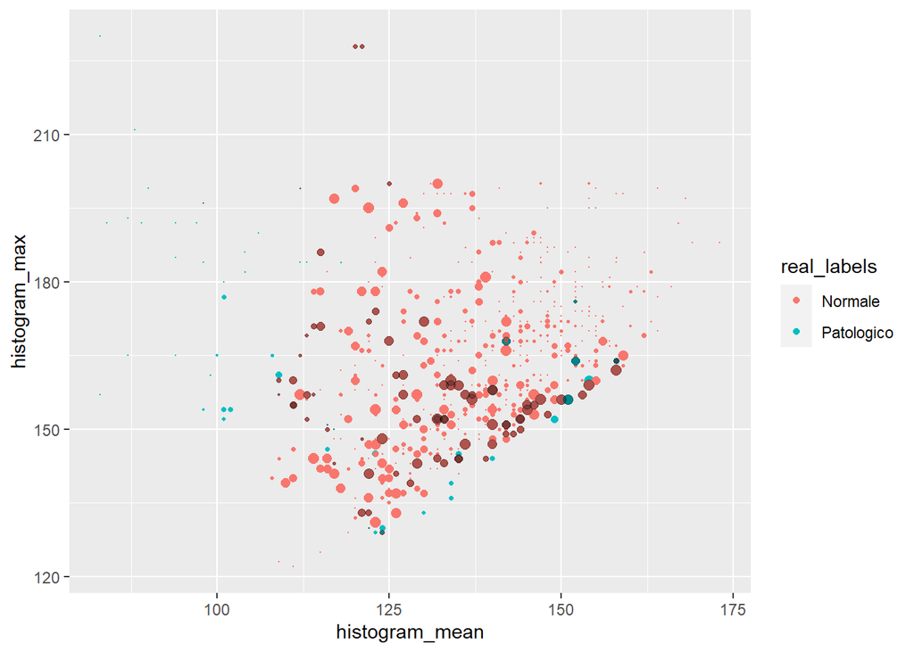

```r
prob.post_incertezza<- tibble(PREDICTION@proba) %>%
  rowwise() %>% # operiamo riga per riga
  mutate(incertezza = 1 - max(c_across(everything())))


data_test %>%
  ggplot(mapping = aes(x=histogram_mean , y = histogram_max, color = real_labels)) +
  geom_point(size=prob.post_incertezza$incertezza*5)+
  geom_point(data = filter(data_test,etichette_prediction_oversampling != real_labels),
             color = "black", alpha = 0.3,size=prob.post_incertezza$incertezza[etichette_prediction_oversampling != real_labels]*5)
```

si può notare che le etichette dei malati sono ben evidenziate anche se poste lontane dal baricentro del gruppo dei malati